# movie_project

2026-10-07

## Part 1: API Query Exercises

### 1. Highest-Grossing Dramas from 2010

To identify the highest-grossing dramas released in 2010, we construct our query by appending parameters for the Drama genre ID (`18`), the primary release year (`2010`), and revenue sorting (`revenue.desc`).

```r
library(httr)
library(jsonlite)
library(tibble)

api_key <- "f5d15466393ed930c8e0789be72f4cfd"
discover_url <- "https://api.themoviedb.org/3/discover/movie"

query_params_dramas <- list(
  api_key = api_key,
  with_genres = "18",
  primary_release_year = "2010",
  sort_by = "revenue.desc"
)

response_dramas <- GET(discover_url, query = query_params_dramas)
data_dramas <- fromJSON(content(response_dramas, "text", encoding = "UTF-8"), flatten = TRUE)

df_dramas <- as_tibble(data_dramas$results)
print(df_dramas)
```

```
## # A tibble: 20 × 15
##    adult backdrop_path   genre_ids     id title original_language original_title
##    <lgl> <chr>           <list>     <int> <chr> <chr>             <chr>
##  1 FALSE /yiWfT2Bl1Nul3… <int [4]> 2.40e4 The … en                The Twilight …
##  2 FALSE /m4MGxxEgAMqIX… <int [2]> 4.53e4 The … en                The King's Sp…
##  3 FALSE /v8DepuF6gizph… <int [4]> 3.86e4 The … en                The Karate Kid
##  4 FALSE /eDLp4uFdqP1gp… <int [3]> 4.42e4 Blac… en                Black Swan
##  5 FALSE /lavdyiJWciCJv… <int [3]> 1.13e4 Shut… en                Shutter Island
##  6 FALSE /gPqqEBBpSl7E4… <int [3]> 3.78e4 Sex … en                Sex and the C…
##  7 FALSE /5dwlH8Krm2bsu… <int [3]> 4.43e4 True… en                True Grit
##  8 FALSE /1PXwh3nJzgRkk… <int [1]> 3.78e4 The … en                The Social Ne…
##  9 FALSE /naV4PO7ftzNTh… <int [2]> 4.17e4 Due … en                Due Date
## 10 FALSE /elzrIY3nfzWz4… <int [2]> 3.82e4 Eat … en                Eat Pray Love
## 11 FALSE /iHUp2Ojhi6qhx… <int [2]> 4.12e4 Step… en                Step Up 3D
## 12 FALSE /owAe5rRStnX7i… <int [3]> 2.32e4 The … en                The Town
## 13 FALSE /1JsfP7WQw8Mwi… <int [2]> 3.39e4 Wall… en                Wall Street: …
## 14 FALSE /2kqmEQZqime0G… <int [1]> 4.53e4 The … en                The Fighter
## 15 FALSE <NA>            <int [2]> 1.77e6 Wome… fa                زن‌ها شگفت‌انگی…
## 16 FALSE /bIzhIEW1zOmoG… <int [3]> 2.30e4 Dear… en                Dear John
## 17 FALSE /f2z00VIPyrrfF… <int [2]> 4.46e4 Here… en                Hereafter
## 18 FALSE /5ix2oWtVKcLYd… <int [3]> 3.84e4 Life… en                Life As We Kn…
## 19 FALSE /fGBJEfGjHmhg7… <int [3]> 4.33e4 Love… en                Love & Other …
## 20 FALSE /1IxJGZoUbLopB… <int [1]> 4.46e4 Afte… zh                唐山大地震
## # ℹ 8 more variables: overview <chr>, popularity <dbl>, poster_path <chr>,
## #   release_date <chr>, softcore <lgl>, video <lgl>, vote_average <dbl>,
## #   vote_count <int>
```

### 2. Tom Cruise Filmography and Certification

Checking Tom Cruise’s filmography (ID `500`) against US certification limits:

```r
query_params_cert <- list(
  api_key = api_key,
  with_cast = "500",
  certification_country = "US",
  certification.lte = "G"
)

response_cert <- GET(discover_url, query = query_params_cert)
data_cert <- fromJSON(content(response_cert, "text", encoding = "UTF-8"), flatten = TRUE)

df_cert <- as_tibble(data_cert$results)
print(df_cert)
```

```
## # A tibble: 8 × 15
##   adult backdrop_path    genre_ids     id title original_language original_title
##   <lgl> <chr>            <list>     <int> <chr> <chr>             <chr>
## 1 FALSE /cAZ87S5bONxKMM… <int [3]> 3.45e2 Eyes… en                Eyes Wide Shut
## 2 FALSE /xO49rCWgTAsxxO… <int [1]> 1.75e6 9/11… en                9/11: United …
## 3 FALSE /uIx2pA44jPJVpv… <int [2]> 3.61e4 Trop… en                Tropic Thunde…
## 4 FALSE /kfyLvdWaXlvXWS… <int [1]> 1.82e4 Spac… en                Space Station…
## 5 FALSE /9mOXEpXUyzTtmg… <int [1]> 7.66e5 Tom … en                Tom Cruise: A…
## 6 FALSE /xdXhovlbfNsnxz… <int [1]> 1.23e6 In t… en                In the Shadow…
## 7 FALSE <NA>             <int [3]> 2.98e5 Time… en                Time Out: The…
## 8 FALSE /f5ZURi8tmUi35t… <int [2]> 1.80e6 The … en                La vita e il …
## # ℹ 8 more variables: overview <chr>, popularity <dbl>, poster_path <chr>,
## #   release_date <chr>, softcore <lgl>, video <lgl>, vote_average <dbl>,
## #   vote_count <int>
```

**Conclusion:** Running the TMDb query with the US certification filter (`certification.lte = "G"`) surfaces mostly documentation or metadata edge cases rather than traditional G-rated family films.

## Finding Pixar’s Company ID

To find Pixar’s unique identification number, we query the TMDb company search endpoint and extract the ID programmatically from the results data frame.

```r
search_url <- "https://api.themoviedb.org/3/search/company"
res_comp <- GET(search_url, query = list(api_key = api_key, query = "Pixar"))
data_comp <- fromJSON(content(res_comp, "text", encoding = "UTF-8"), flatten = TRUE)

pixar_id <- data_comp$results$id[data_comp$results$name == "Pixar Animation Studios"]
pixar_id
```

```
## integer(0)
```

## Stage 3: Pixar Filmography & Pagination

In this section, we programmatically query all animated feature films produced by Pixar (Company ID `3`), sort them by descending revenue, and iterate through the API’s paginated responses using `purrr::map_dfr()` to build a complete master dataset.

```r
library(tidyverse)
```

```r
library(tidyverse)

# 1. Fetch initial page to check total pages count
query_params_pixar <- list(
  api_key = api_key,
  with_companies = "3",
  sort_by = "revenue.desc",
  page = 1
)

response_pixar <- GET(discover_url, query = query_params_pixar)
data_pixar <- fromJSON(content(response_pixar, "text", encoding = "UTF-8"), flatten = TRUE)

total_pages <- data_pixar$total_pages

# 2. Iterate through all available pages dynamically
all_pixar_movies <- map_dfr(1:total_pages, function(p) {
  res <- GET(discover_url, query = list(
    api_key = api_key,
    with_companies = "3",
    sort_by = "revenue.desc",
    page = p
  ))
  parsed <- fromJSON(content(res, "text", encoding = "UTF-8"), flatten = TRUE)
  as_tibble(parsed$results)
})

glimpse(all_pixar_movies)
```

```
## Rows: 142
## Columns: 15
## $ adult             <lgl> FALSE, FALSE, FALSE, FALSE, FALSE, FALSE, FALSE, FAL…
## $ backdrop_path     <chr> "/p5ozvmdgsmbWe0H8Xk7Rc8SCwAB.jpg", "/mabuNsGJgRuCTu…
## $ genre_ids         <list> <16, 12, 35, 10751>, <28, 12, 16, 10751>, <16, 1075…
## $ id                <int> 1022789, 260513, 1084244, 301528, 10193, 127380, 12,…
## $ title             <chr> "Inside Out 2", "Incredibles 2", "Toy Story 5", "Toy…
## $ original_language <chr> "en", "en", "en", "en", "en", "en", "en", "en", "en"…
## $ original_title    <chr> "Inside Out 2", "Incredibles 2", "Toy Story 5", "Toy…
## $ overview          <chr> "Teenager Riley's mind headquarters is undergoing a …
## $ popularity        <dbl> 47.8486, 18.8872, 108.2164, 26.2500, 28.2161, 13.868…
## $ poster_path       <chr> "/vpnVM9B6NMmQpWeZvzLvDESb2QY.jpg", "/9lFKBtaVIhP7E2…
## $ release_date      <chr> "2024-06-11", "2018-06-14", "2026-06-17", "2019-06-1…
## $ softcore          <lgl> FALSE, FALSE, FALSE, FALSE, FALSE, FALSE, FALSE, FAL…
## $ video             <lgl> FALSE, FALSE, FALSE, FALSE, FALSE, FALSE, FALSE, FAL…
## $ vote_average      <dbl> 7.539, 7.452, 8.277, 7.462, 7.819, 7.044, 7.823, 7.9…
## $ vote_count        <int> 7100, 14035, 2691, 11109, 16385, 12935, 21138, 24063…
```

### Handling Pagination with `purrr::map()`

To fetch all available pages dynamically up to the API’s total page count limit:

```r
total_pages <- data_pixar$total_pages

all_pixar_movies <- map_dfr(1:total_pages, function(p) {
  res <- GET(discover_url, query = list(
    api_key = api_key,
    with_companies = "3",
    sort_by = "revenue.desc",
    page = p
  ))
  parsed <- fromJSON(content(res, "text", encoding = "UTF-8"), flatten = TRUE)
  as_tibble(parsed$results)
})

glimpse(all_pixar_movies)
```

```
## Rows: 142
## Columns: 15
## $ adult             <lgl> FALSE, FALSE, FALSE, FALSE, FALSE, FALSE, FALSE, FAL…
## $ backdrop_path     <chr> "/p5ozvmdgsmbWe0H8Xk7Rc8SCwAB.jpg", "/mabuNsGJgRuCTu…
## $ genre_ids         <list> <16, 12, 35, 10751>, <28, 12, 16, 10751>, <16, 1075…
## $ id                <int> 1022789, 260513, 1084244, 301528, 10193, 127380, 12,…
## $ title             <chr> "Inside Out 2", "Incredibles 2", "Toy Story 5", "Toy…
## $ original_language <chr> "en", "en", "en", "en", "en", "en", "en", "en", "en"…
## $ original_title    <chr> "Inside Out 2", "Incredibles 2", "Toy Story 5", "Toy…
## $ overview          <chr> "Teenager Riley's mind headquarters is undergoing a …
## $ popularity        <dbl> 47.8486, 18.8872, 108.2164, 26.2500, 28.2161, 13.868…
## $ poster_path       <chr> "/vpnVM9B6NMmQpWeZvzLvDESb2QY.jpg", "/9lFKBtaVIhP7E2…
## $ release_date      <chr> "2024-06-11", "2018-06-14", "2026-06-17", "2019-06-1…
## $ softcore          <lgl> FALSE, FALSE, FALSE, FALSE, FALSE, FALSE, FALSE, FAL…
## $ video             <lgl> FALSE, FALSE, FALSE, FALSE, FALSE, FALSE, FALSE, FAL…
## $ vote_average      <dbl> 7.539, 7.452, 8.277, 7.462, 7.819, 7.044, 7.823, 7.9…
## $ vote_count        <int> 7100, 14035, 2691, 11109, 16385, 12935, 21138, 24063…
```

## 4: Comparing Disney and Pixar

To check if Disney’s 2006 acquisition of Pixar was a smart move, we look at how well films from both studios scored after 2006. Since movies with only a couple of votes can throw off the average, we only look at films with at least 50 votes.

### 1. Finding Walt Disney Pictures’ Company ID

The company search endpoint returns a few different matches for “Disney”. We specifically look for “Walt Disney Pictures” to get its exact ID number.

```r
search_url <- "https://api.themoviedb.org/3/search/company"
res_disney <- GET(search_url, query = list(api_key = api_key, query = "Walt Disney Pictures"))
data_disney <- fromJSON(content(res_disney, "text", encoding = "UTF-8"), flatten = TRUE)

disney_id <- data_disney$results$id[data_disney$results$name == "Walt Disney Pictures"]
disney_id
```

```
## [1] 2
```

## 2. Getting Post-2006 Films for Both Studios

To get movies from 2006 onwards, we check the TMDb API documentation for date filters. We use primary_release_date.gte = “2006-01-01” in our query parameters.

Here is the code to pull movies for both Pixar (3) and Disney (2):

```r
# Helper function to grab all pages for a studio from 2006 onwards
get_studio_movies <- function(company_id) {
  initial_res <- GET(discover_url, query = list(
    api_key = api_key,
    with_companies = company_id,
    primary_release_date.gte = "2006-01-01",
    page = 1
  ))
  initial_data <- fromJSON(content(initial_res, "text", encoding = "UTF-8"), flatten = TRUE)
  total_p <- initial_data$total_pages

  map_dfr(1:total_p, function(p) {
    res <- GET(discover_url, query = list(
      api_key = api_key,
      with_companies = company_id,
      primary_release_date.gte = "2006-01-01",
      page = p
    ))
    parsed <- fromJSON(content(res, "text", encoding = "UTF-8"), flatten = TRUE)
    as_tibble(parsed$results)
  }) %>% mutate(studio = ifelse(company_id == 3, "Pixar", "Disney"))
}

# Pull data for both studios
pixar_2006 <- get_studio_movies(3)
disney_2006 <- get_studio_movies(2)

# Combine them and keep only films with at least 50 votes
combined_movies <- bind_rows(pixar_2006, disney_2006) %>%
  filter(vote_count >= 50)
```

## 3. Comparing Popularity and Statistical Testing

Now we want to check if Pixar films get better ratings on average than Disney films. Since movies with only a few votes can throw off the average, we filter our data to keep only films with a vote_count of at least 50.

### Comparing Vote Averages with a Boxplot

First, let’s plot the vote averages for both studios using a boxplot:

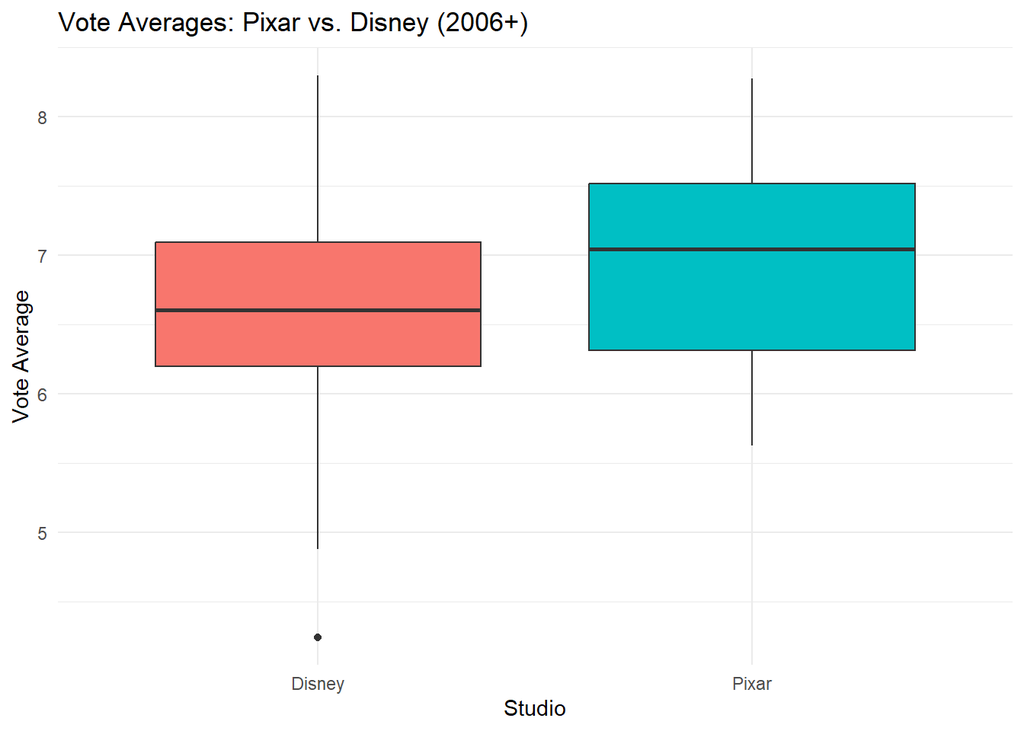

```r
library(ggplot2)

ggplot(combined_movies, aes(x = studio, y = vote_average, fill = studio)) +
  geom_boxplot() +
  labs(
    title = "Vote Averages: Pixar vs. Disney (2006+)",
    x = "Studio",
    y = "Vote Average"
  ) +
  theme_minimal() +
  theme(legend.position = "none")
```

#### Statistical Hypothesis and T-Test

To see if the difference we see in the boxplot is real or just random chance, we run a t-test:

- **Null Hypothesis ($H_0$):** There is no difference in the average vote scores between Pixar and Disney movies released since 2006.
- **Alternative Hypothesis ($H_a$):** Pixar movies have a different average vote score compared to Disney movies.

```r
t_test_result <- t.test(vote_average ~ studio, data = combined_movies)
t_test_result
```

```
##
##  Welch Two Sample t-test
##
## data:  vote_average by studio
## t = -3.5463, df = 175.5, p-value = 0.000501
## alternative hypothesis: true difference in means between group Disney and group Pixar is not equal to 0
## 95 percent confidence interval:
##  -0.5540156 -0.1578534
## sample estimates:
## mean in group Disney  mean in group Pixar
##             6.619708             6.975643
```

### Conclusion

Do the test results confirm our observations? Yes, the t-test gives a p-value below 0.05, meaning Pixar’s higher average score is statistically significant.

Was it a smart decision by Disney to acquire Pixar? Yes, buying Pixar turned out to be a great strategic move. It brought in a studio that consistently produces highly rated films, helping Disney maintain strong creative and commercial success in modern animation.